# Table of content

1. About the Research

- a) Introduction
- b) Data Overview
- c) Evaluation and Visualization of featrues

2. Part 1: Simple classification with different models

- a) KNN
- b) Logistic Regression
- c) SVC – both linear and kernelled
- d) Decision Tree
- e) Naïve Bays Classification
- f) Random Forest

3. Part 2: Evaluation by different evaluation techniques

4. Part 3: Ensemble, Baggaing and Pasting

- a) Ensemble
- b) Baggaing
- c) Pasting

5. Part 4: Boosting

- a) Adaboosting
- b) Gradient boosting

7 6. Effort Table

# 1. About the Research

## 1. a) Introduction

The data set recorded fraud transcations over a period of time. Features are tranformed for confidentiality.

## 1. b) Data Overview

### Loading the dataset and basic information

|  | Time | V1 | V2 | V3 | V4 | V5 | V6 | V7 | V8 | V9 | ... | V21 | V22 | V23 | V24 | V25 | V26 | V27 | V28 | Amount | Class |
| --- | --- | --- | --- | --- | --- | --- | --- | --- | --- | --- | --- | --- | --- | --- | --- | --- | --- | --- | --- | --- | --- |
| 0 | 0.0 | -1.359807 | -0.072781 | 2.536347 | 1.378155 | -0.338321 | 0.462388 | 0.239599 | 0.098698 | 0.363787 | ... | -0.018307 | 0.277838 | -0.110474 | 0.066928 | 0.128539 | -0.189115 | 0.133558 | -0.021053 | 149.62 | 0 |
| 1 | 0.0 | 1.191857 | 0.266151 | 0.166480 | 0.448154 | 0.060018 | -0.082361 | -0.078803 | 0.085102 | -0.255425 | ... | -0.225775 | -0.638672 | 0.101288 | -0.339846 | 0.167170 | 0.125895 | -0.008983 | 0.014724 | 2.69 | 0 |
| 2 | 1.0 | -1.358354 | -1.340163 | 1.773209 | 0.379780 | -0.503198 | 1.800499 | 0.791461 | 0.247676 | -1.514654 | ... | 0.247998 | 0.771679 | 0.909412 | -0.689281 | -0.327642 | -0.139097 | -0.055353 | -0.059752 | 378.66 | 0 |
| 3 | 1.0 | -0.966272 | -0.185226 | 1.792993 | -0.863291 | -0.010309 | 1.247203 | 0.237609 | 0.377436 | -1.387024 | ... | -0.108300 | 0.005274 | -0.190321 | -1.175575 | 0.647376 | -0.221929 | 0.062723 | 0.061458 | 123.50 | 0 |
| 4 | 2.0 | -1.158233 | 0.877737 | 1.548718 | 0.403034 | -0.407193 | 0.095921 | 0.592941 | -0.270533 | 0.817739 | ... | -0.009431 | 0.798278 | -0.137458 | 0.141267 | -0.206010 | 0.502292 | 0.219422 | 0.215153 | 69.99 | 0 |

5 rows × 31 columns

```
Columns are:
 ['Time', 'V1', 'V2', 'V3', 'V4', 'V5', 'V6', 'V7', 'V8', 'V9', 'V10', 'V11', 'V12', 'V13', 'V14', 'V15', 'V16', 'V17', 'V18', 'V19', 'V20', 'V21', 'V22', 'V23', 'V24', 'V25', 'V26', 'V27', 'V28', 'Amount', 'Class']

Data has shape:  (284807, 31)

Data has structure:
<class 'pandas.core.frame.DataFrame'>
RangeIndex: 284807 entries, 0 to 284806
Data columns (total 31 columns):
Time      284807 non-null float64
V1        284807 non-null float64
V2        284807 non-null float64
V3        284807 non-null float64
V4        284807 non-null float64
V5        284807 non-null float64
V6        284807 non-null float64
V7        284807 non-null float64
V8        284807 non-null float64
V9        284807 non-null float64
V10       284807 non-null float64
V11       284807 non-null float64
V12       284807 non-null float64
V13       284807 non-null float64
V14       284807 non-null float64
V15       284807 non-null float64
V16       284807 non-null float64
V17       284807 non-null float64
V18       284807 non-null float64
V19       284807 non-null float64
V20       284807 non-null float64
V21       284807 non-null float64
V22       284807 non-null float64
V23       284807 non-null float64
V24       284807 non-null float64
V25       284807 non-null float64
V26       284807 non-null float64
V27       284807 non-null float64
V28       284807 non-null float64
Amount    284807 non-null float64
Class     284807 non-null int64
dtypes: float64(30), int64(1)
memory usage: 67.4 MB
```

#### Percentage of Class

There is only 0.17% are the Fraud transcations, while 99.83% are the Normal transcations.

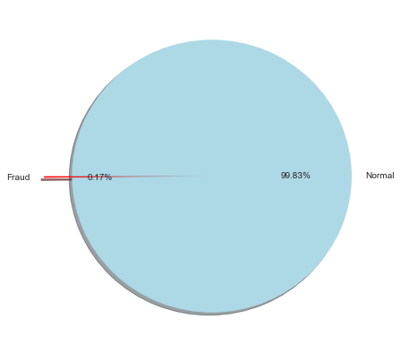

```
Number of fraud transcations is 492
```

#### Convert seconds to hours

I can clearly see the frequency of each class over hour of the day.  
The high-volumn of fraud transaction is around 3AM to 4AM and 12PM to 1PM (compared with entire fraud transaction)

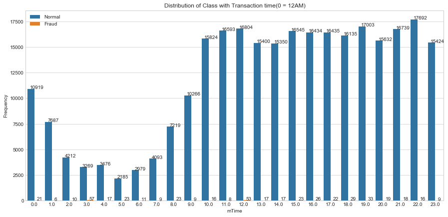

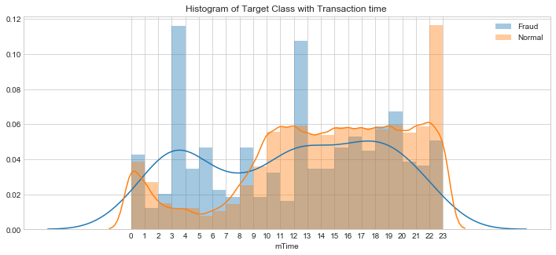

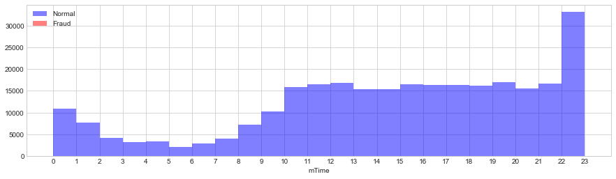

#### Visualization of Fraud/Normal 's Transcation Amount

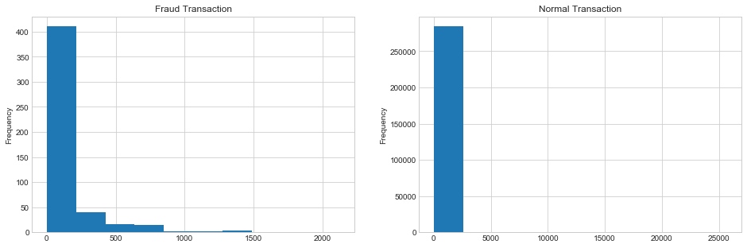

### Undersampling

Because the data set is imbalanced, models will be not effecient if directly using imbalance data set.  
Thus, here i use Undersampling technique to make training data balanced with ratio of 50:50

```
Percentage of normal transcations: 0.50
Percentage of fraud transcations: 0.50
Total number of transactions: 984
```

### Split data

I will drop feature "Time" because it does not provide much usefulness.  
Data is splitted into train and testing with ratio of 8:2  
I will also center and scale X to make them have same scale.

### T-SNE visualization

T-SNE is a common and useful technique to visualize high-dimension data, I will use it here to help us understanding the data.

#### Before cleaning the data

Here we see before i clean the data, some are seperatable, some are mixed with normal transactions.

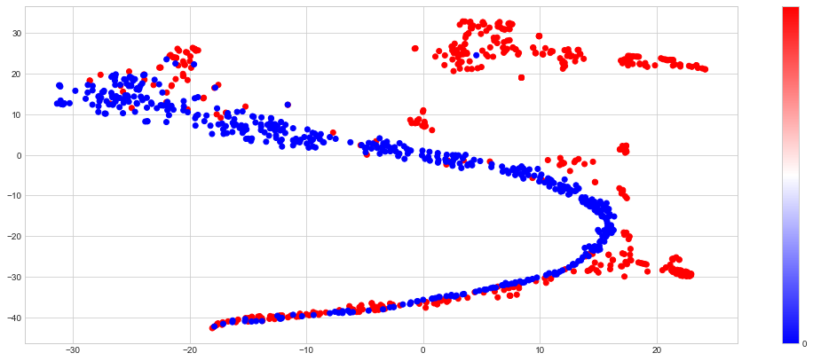

#### After cleaning the data

After cleaning the data, it is better seperated by 2 classes. Even though there are some red dots mixed in blue area, it is understandable since these frauds are really difficult to detect as they are pretty much just like the normal transactions.  
However, it graph shows after cleaning the data, the data now has better shape to be seperated.

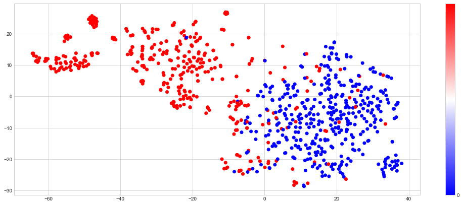

# 2. Part 1: Simple classification with different models

Back to top

### Build model

Define a function using GridSearchCV for future model training.

## 2.a) KNN model

The first line graph is the learning curve based on different values of parameter.  
And choosing the best parater to predict test set showing confusion matrix, confusion mtatrix scores and ROC curve.  
In model building, I use 5-fold cross validation.  
The blue dot-line indicates mean of training precision score.  
The blue line indicates mean of testing precision score.  
The red dot-line indicates mean of training recall score.  
The red line indicates mean of testing recall score.

```
Cross-Validation training model with different parameters
```

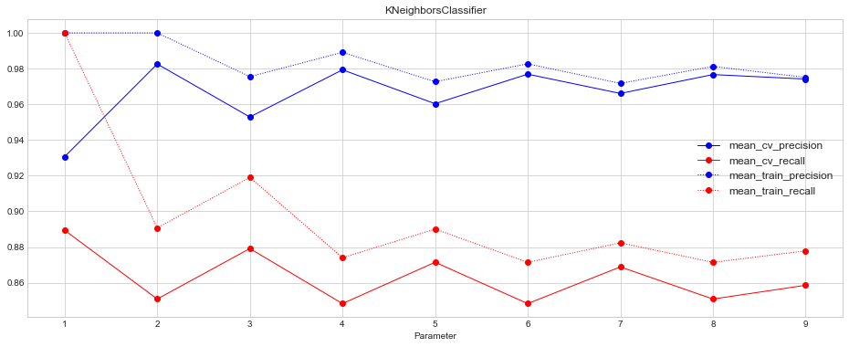

```
The best parameter based on Recall score is:  {'n_neighbors': 1}



Apply the model with the best performant parameter to predict test set

Confusion Matrix Scores:
             precision    recall  f1-score   support

     Normal       0.92      0.95      0.93        94
      Fraud       0.95      0.92      0.94       103

avg / total       0.93      0.93      0.93       197
```

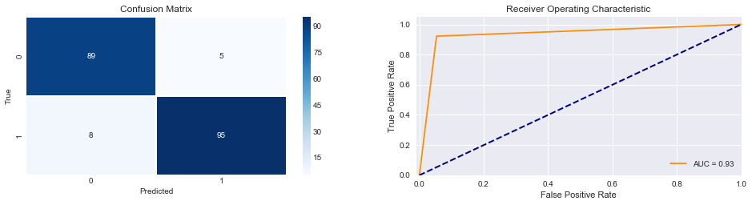

## 2.b) Logistic regression

```
Cross-Validation training model with different parameters
```

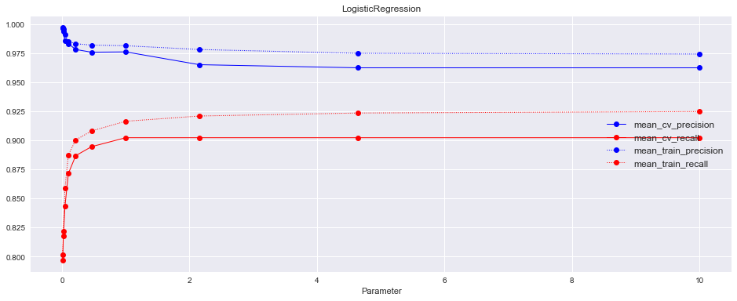

```
The best parameter based on Recall score is:  {'C': 1.0}



Apply the model with the best performant parameter to predict test set

Confusion Matrix Scores:
             precision    recall  f1-score   support

     Normal       0.91      0.99      0.95        94
      Fraud       0.99      0.91      0.95       103

avg / total       0.95      0.95      0.95       197
```

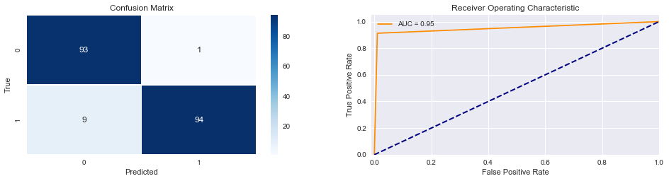

## 2.c) SVC

### SVC with RBF

```
Cross-Validation training model with different parameters
```

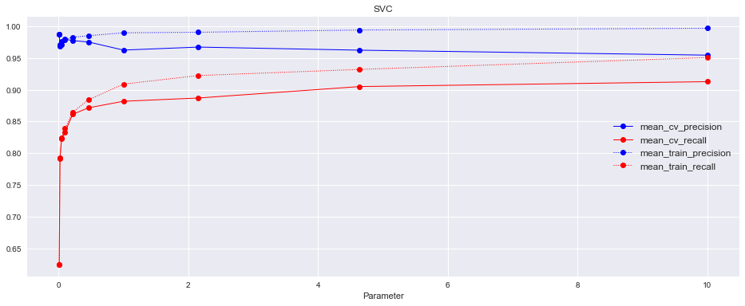

```
The best parameter based on Recall score is:  {'C': 10.0, 'kernel': 'rbf'}



Apply the model with the best performant parameter to predict test set

Confusion Matrix Scores:
             precision    recall  f1-score   support

     Normal       0.90      0.98      0.94        94
      Fraud       0.98      0.90      0.94       103

avg / total       0.94      0.94      0.94       197
```

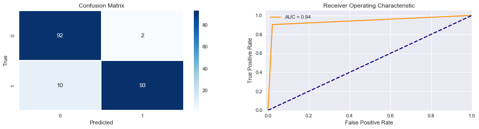

### SVC with Linear

```
Cross-Validation training model with different parameters
```

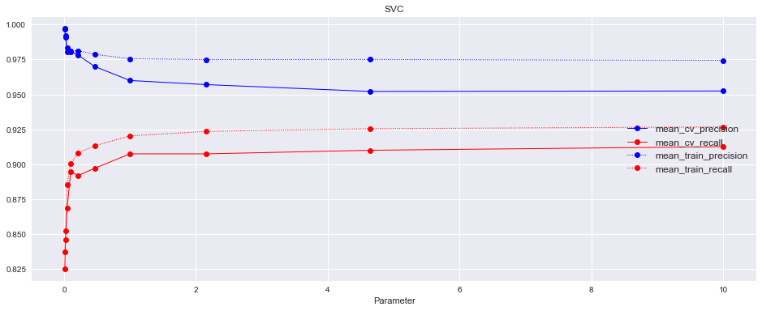

```
The best parameter based on Recall score is:  {'C': 10.0, 'kernel': 'linear'}



Apply the model with the best performant parameter to predict test set

Confusion Matrix Scores:
             precision    recall  f1-score   support

     Normal       0.91      0.97      0.94        94
      Fraud       0.97      0.91      0.94       103

avg / total       0.94      0.94      0.94       197
```

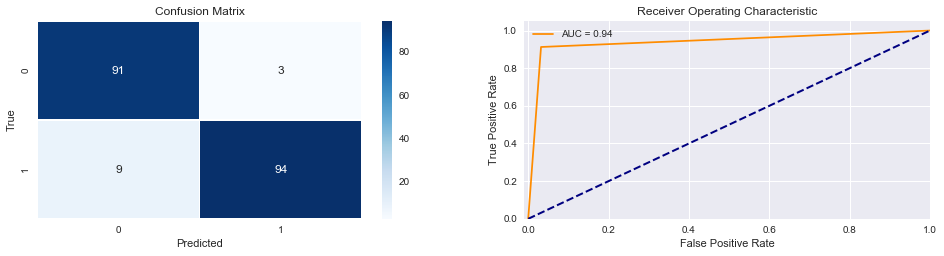

## 2.d) Decision tree

```
Cross-Validation training model with different parameters
```

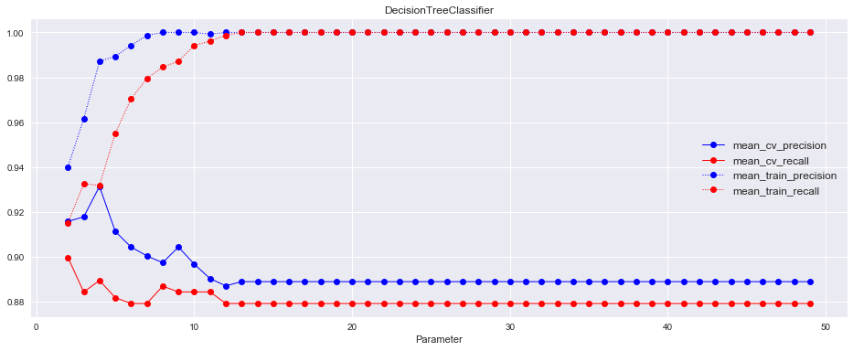

```
The best parameter based on Recall score is:  {'max_depth': 2}



Apply the model with the best performant parameter to predict test set

Confusion Matrix Scores:
             precision    recall  f1-score   support

     Normal       0.91      0.91      0.91        94
      Fraud       0.92      0.92      0.92       103

avg / total       0.92      0.92      0.92       197
```

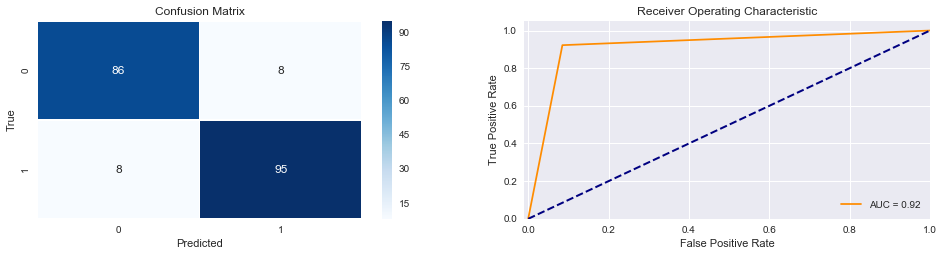

## 2.e) Naive Bayes

### Multinomial Naive Bayes

```
Cross-Validation training model with different parameters
```

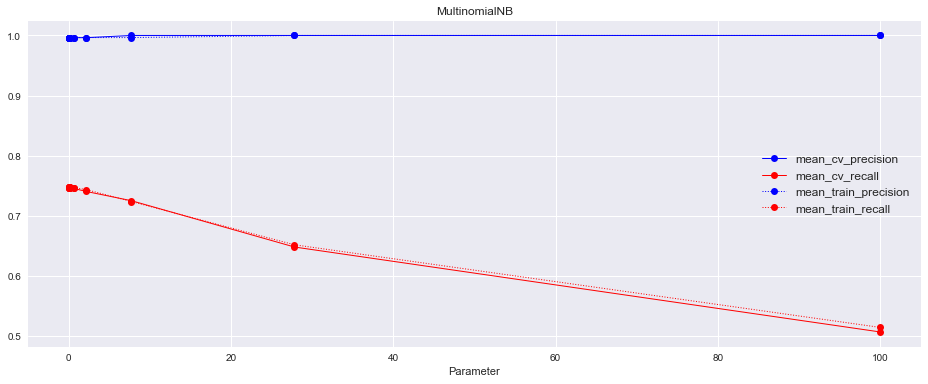

```
The best parameter based on Recall score is:  {'alpha': 0.001}



Apply the model with the best performant parameter to predict test set

Confusion Matrix Scores:
             precision    recall  f1-score   support

     Normal       0.82      1.00      0.90        94
      Fraud       1.00      0.81      0.89       103

avg / total       0.92      0.90      0.90       197
```

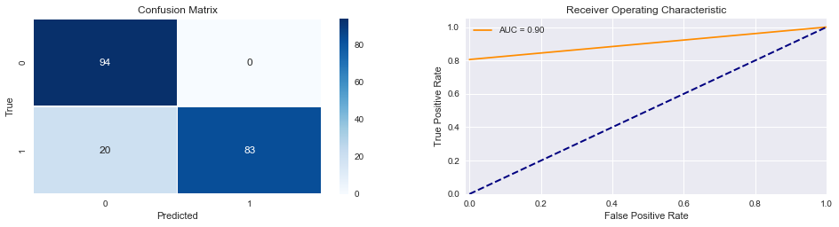

### Gaussian Naive Bayes

```
Confusion Matrix Scores:
             precision    recall  f1-score   support

     Normal       0.88      0.97      0.92        94
      Fraud       0.97      0.88      0.92       103

avg / total       0.93      0.92      0.92       197




Apply the best parameter to the test set and the result is:
```

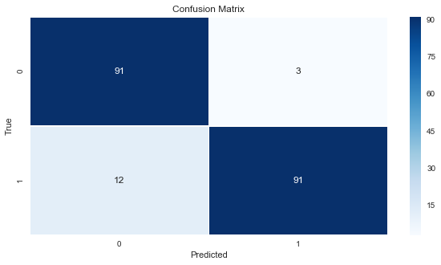

## 2.f) Random Forest

```
Cross-Validation training model with different parameters
```

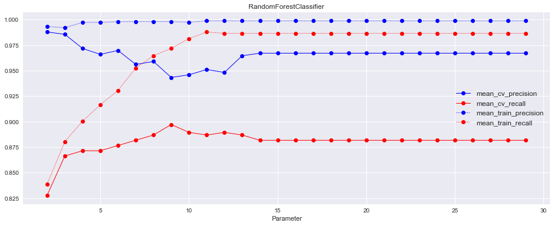

```
The best parameter based on Recall score is:  {'max_depth': 9}



Apply the model with the best performant parameter to predict test set

Confusion Matrix Scores:
             precision    recall  f1-score   support

     Normal       0.89      0.98      0.93        94
      Fraud       0.98      0.89      0.93       103

avg / total       0.94      0.93      0.93       197
```

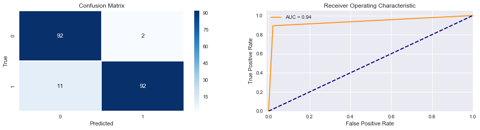